# Практична робота №4

## Тема: Схема Бернуллі.

## Мета: Набути практичних навичок у розв’язанні типових задач в рамках схеми Бернуллі

## 1. Ймовірність появи випадкової події в кожному з належних випробуваньнезмінна і дорівнює 0,7. Провели 900 випробувань. Обчислити ймовірність наступних дій:

## 1) подія відбувається в 620 випробуваннях;

## 2) подія відбувається не менше 620 разів.

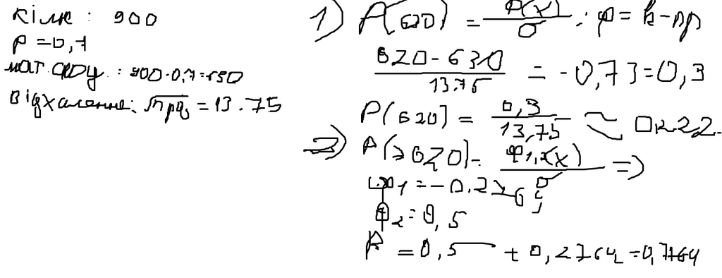

## 2. Ймовірність появи випадкової події при одному випробуванні незмінна і дорівнює 0,6. Знайти ймовірність того, що при 400 випробуваннях відносна частота появи події відхиляється від ймовірності 𝑝 = 0,6 не більше, ніж на 0,004.

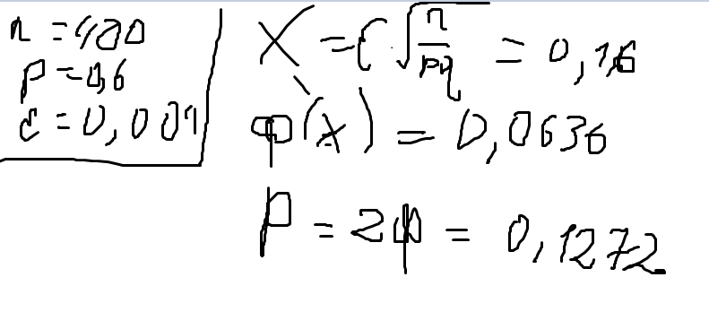

## 3. Ймовірність появи випадкової події в кожному з належних іспитів незмінна і дорівнює 0,8. Знайти, яке відхилення відносної частоти появи події від її ймовірності очікується з ймовірністю 0,999 при 10000 іспитах.

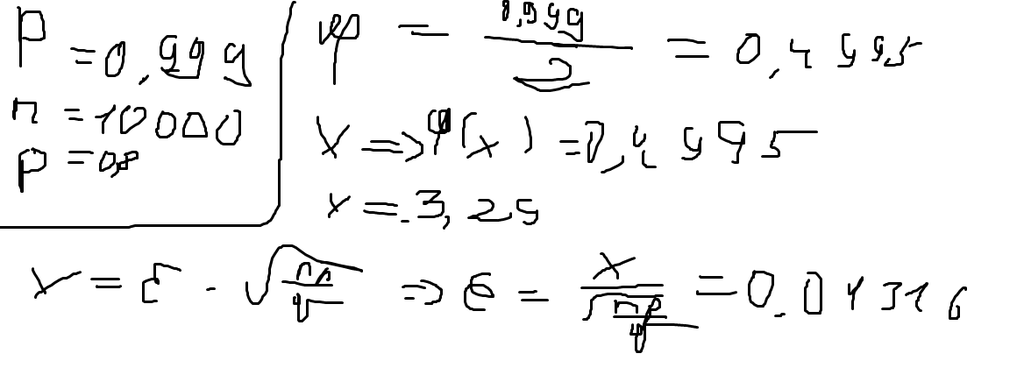

## 4. Телефонна станція обслуговує 5000 абонентів. Ймовірність того, що протягом хвилини від абонента надійде запит до станції незмінна і дорівнює 0.01.

## Знайти:

## а) найбільш ймовірну кількість запитів;

## б) ймовірність найбільш ймовірної кількості запитів;

## в) ймовірність того, що протягом хвилини надійде 100 запитів від клієнтів;

## г) ймовірність того, що протягом хвилини надійде не більше 5 запитів.

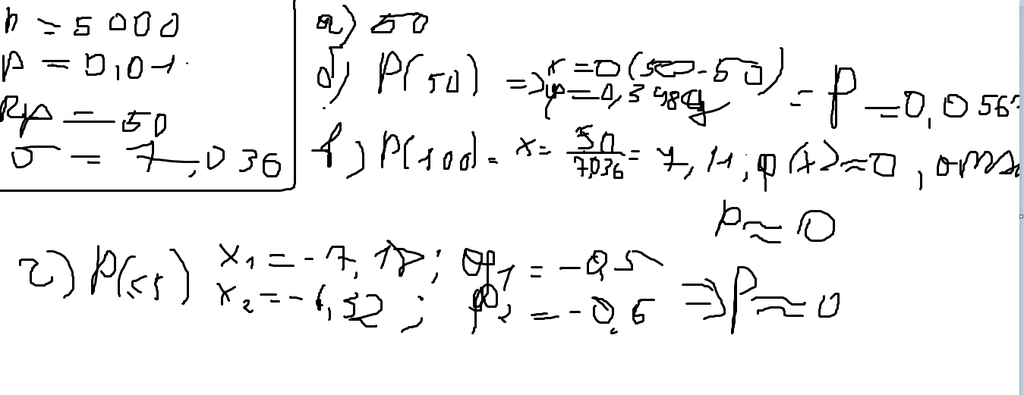

## 5. У шухляді міститься 7 стандартних і 3 бракованих деталі. Деталі із шухляди беруть по одній з поверненням. Обчислити ймовірність наступних дій:

## а) стандартна деталь з’явиться 70 разів із 100;

## б) стандартна деталь з’явиться від 65 до 80 разів із 100.

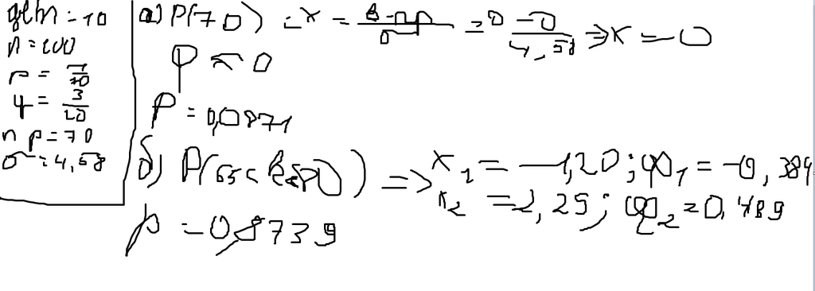

## Контрольні питання

### 1. Це послідовність незалежних і повторюваних випадкових експериментів, кожен з яких має лише два взаємовиключних результати.

### 2. Фіксована кількість випробувань, два можливих взаємовиключних результата , незалежність випробувань , стала ймовірність.

### 3. Загальне: Два можливих результати, фіксована кількість випробувань. Відмінне - Спосіб відбору (Бернулі - з поверненням, Розподіл - без повернення), у Бернулі незалежні випробуваня, а у розподілу залежні, у Бернулі стала ймовірність, а у розподілу змінна.

### 4. Pn(k) = Cnk * p^k * q^(n-k)

### 5. Можна привести підкидання монети або грального кубика, а також контроль якості виробництва.

## Висновок

### На цьому практичному занятті ми познайомилися зі схемою Бернуллі та набули практичних навичок у розв’язанні типових задач в рамках цієї схеми.